# Lab_12

Fantastic Four

# Functions Defined

```r
#for defining functions (?):
showLevels <- function(data_input){
  return(unique(data_input))
}

summaryStats <- function(data_input,continent_in,start_year,end_year,column_in){
  #main function to return the summary stats for a certain dataset and column for years
  x2 <- filter(data_input,continent == continent_in,year>=start_year,year<=end_year)
  x <- sample_n(x2,10,replace=TRUE)
  df <- data.frame(continent_in,start_year,end_year,mean(x[[column_in]]),median(x[[column_in]]),min(x[[column_in]]),max(x[[column_in]]),IQR(x[[column_in]]))
  return(df)
}

calc_summaryStats <- function(data_input,continent_in,start_year,end_year,column_in){
  yearA <- start_year
  output_summary <- 0

  while(yearA < end_year){
    output_summary <- rbind(output_summary, summaryStats(data_input,continent_in,yearA,yearA+9,column_in))
    yearA <- yearA + 10
  }
  output_summary <- output_summary[-1,]
  colnames(output_summary) <- c("continent","start_year","end_year","mean","median","minimum","maximum","IQR")
  return(output_summary)
}

runAll_calc_summaryStats <- function(data_input,start_year,end_year,column_in){
  #cont = c("Africa","Asia","Americas","Europe","Oceania")
  output_dataframe <- 0
  fun <- showLevels(data_input$continent)
  for(item in fun){
    output_dataframe <- rbind(output_dataframe, calc_summaryStats(gapminder,item,start_year,end_year,column_in))
  }
  return(output_dataframe)

}
```

# Overall Question

What are the general trends in population and life expectancy over time? Is there an overall relationship between these two variables?

These questions are significant because they can lead to theoretical analysis of the trend countries will face in years to come of population growth and life expectancy, given that there is no drastic impact to the populations’ health in the future. Using this data, we can also observe, at different time periods, if major events in the world correspond to changes in the population or a countries life expectancy.

```r
# Is there a correlation between life expectancy and population size?
runAll_calc_summaryStats(gapminder,1950,2010,"pop")
```

```
##    continent start_year end_year      mean    median  minimum    maximum
## 1       <NA>          0        0         0         0        0          0
## 2       Asia       1950     1959  22178525   5993566   138655   92388772
## 3       Asia       1960     1969  68781137  21120516   358266  454000000
## 4       Asia       1970     1979 232106507 110162302   141500  862030000
## 5       Asia       1980     1989 125438837  10368611  1203634 1084035000
## 6       Asia       1990     1999 139605260  18698655   417129 1164970000
## 7       Asia       2000     2009  34839825  22409182  3389578  135656790
## 21    Europe       1950     1959  10265461   7187586   142938   29579142
## 31    Europe       1960     1969  16473548   9050700  2830000   52986600
## 41    Europe       1970     1979  18744813   8855596   339174   56240143
## 51    Europe       1980     1989  16584870   7440624   233997   56630129
## 61    Europe       1990     1999   8503690   4497686   403756   38253222
## 71    Europe       2000     2009  22993316   8779292  4480560   82398326
## 22    Africa       1950     1959   2770661   1081442   323150   10270856
```

[output cut: 61 more lines]

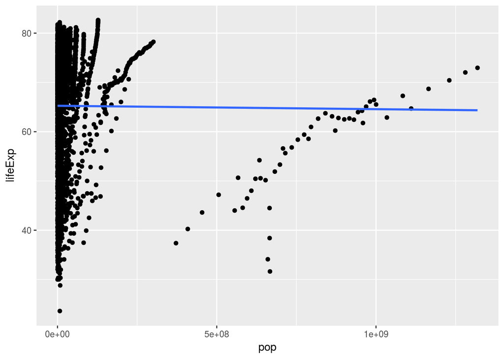

```r
ggplot(gapminder, aes(x = pop, y = lifeExp)) +
  geom_jitter() +
  geom_smooth(se = FALSE, method = "lm")
```

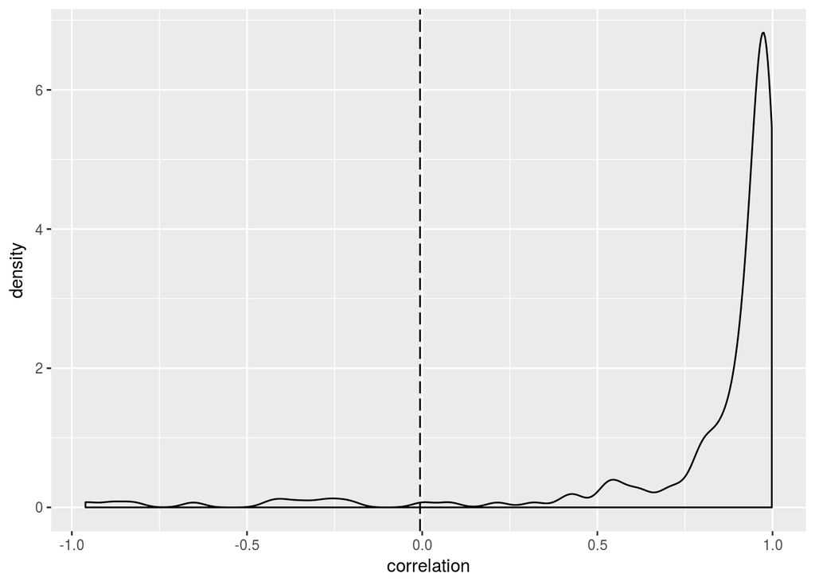

```r
ov_cor <- gapminder %$%
  cor(pop, lifeExp)

gcor <- gapminder %>% group_by(country) %>% summarize(correlation = cor(pop, lifeExp))

ggplot(gcor, aes(x = correlation)) +
  geom_density() +
  geom_vline(xintercept = ov_cor, linetype = "longdash") +
  geom_text(data = NULL, x = ov_cor, y = 10, label = round(ov_cor, 2),
            hjust = -0.1)
```